# Data Expo 2009 - Airline on-time performance

## by (Mahmoud Lotfi)

## Preliminary Wrangling

- The data consists of flight arrival and departure details for all commercial flights within the USA, from October 1987 to April 2008.
- This is a large dataset: there are nearly 120 million records in total, and takes up 1.6 gigabytes of space compressed and 12 gigabytes when uncompressed.
- The data comes originally from RITA where it is described in detail.
- the data in bzipped csv file.
- These files have derivable variables removed, are packaged in yearly chunks and have been more heavily compressed than the originals.
- in this project we will discuss flight delay for **2008** data set

### Individual years:

1987, 1988, 1989, 1990, 1991, 1992, 1993, 1994, 1995, 1996, 1997, 1998, 1999, 2000, 2001, 2002, 2003, 2004, 2005, 2006, 2007, 2008

### Our scope on 2008 dataset

## 01. Flights without cancellation nor divertion dataset:

### What is the structure of your dataset?

> There are 6,851,832 flight observations with 26 features in 2008 without diverted/cancelled flights and missing or incorrect data.

### What is/are the main feature(s) of interest in your dataset?

> Delayed flights in terms of carriers, origin & time.

### What features in the dataset do you think will help support your investigation into your feature(s) of interest?

> ArrDelay, Month, DayOfWeek, DepTime, ArrTime, UniqueCarrier.

## 02. Flights that have been Cancellation:

### What is the structure of your dataset?

> There are 137,434 flight observations with 12 features in 2008.

### What is/are the main feature(s) of interest in your dataset?

- what are the worstest airlines in terms of cancelled flighes?
- what are the most cases of flights cancelled?

### What features in the dataset do you think will help support your investigation into your feature(s) of interest?

> UniqueCarrier, CancellationCode

## 03. Flights that have been diverted:

### What is the structure of your dataset?

> There are 17,265 flight observations with 12 features in 2008.

### What is/are the main feature(s) of interest in your dataset?

> what are the Origin & Dest that have the most diverted flighes?

### What features in the dataset do you think will help support your investigation into your feature(s) of interest?

> Origin & Dest.

## Expoloring Flights dataset:

### 01. Flight dataset Year column:

```
range :  1987-2008
```

```
2008    6851832
Name: Year, dtype: int64
```

### 02. Flight dataset Month column:

```
range :  1-12
```

### Bar plot indicate the number of flights per month

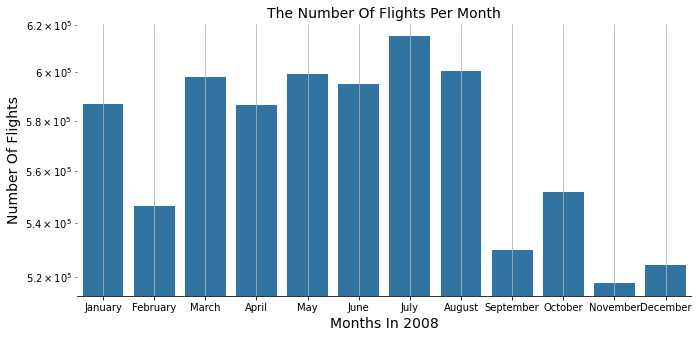

- less flights on winter November , December

### 03. Flight dataset DayofMonth column:

```
range :  1-31
```

### Bar plot indicate the number of flights per day of month

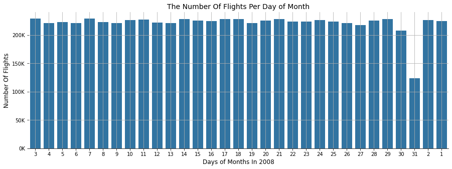

- There are not big difference amonge monthes in the flights number during the days of months, and its natural to be less half flights during 31th.

### 04. Flight dataset DayOfWeek column:

```
range :  1 (Monday) - 7 (Sunday)
```

#### Bar plot indicate the number of flights per day of week

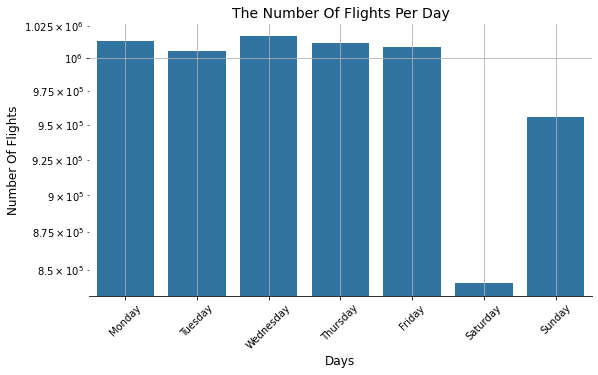

> There are not big difference amonge flights number during working days 'Tuesday', 'Wednesday', 'Thursday', 'Friday' , and less flights during Sunday , and more less in Saturday.

### 05. Flight dataset DepTime column:

```
range :  00:00 AM-11:59 PM
actual departure time (local, hh:mm AM/PM)
```

```
count      6851832
unique        1439
top       05:55 AM
freq         17187
Name: DepTime, dtype: object
```

### line plot indicate the number of actual departed flights over the day time

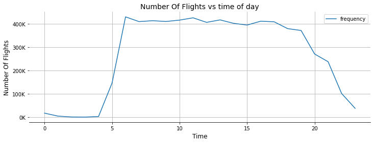

> peak crowd start from 05:00 AM to 6:00 PM

### 06. Flight dataset CRSDepTime column:

```
range :  00:00 AM-11:59 PM
scheduled departure time (local, hh:mm AM/PM)
```

### line plot indicate the number of scheduled departed flights over the day time

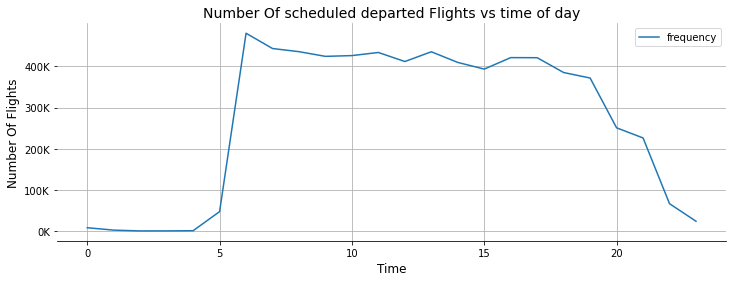

> peak crowd start from 05:00 AM to 6:00 PM

### 07. Flight dataset ArrTime column:

```
range :  00:00 AM-11:59 PM
actual arrival time (local, hh:mm AM/PM)
```

### line plot indicate the number of actual arrival flights over the day time

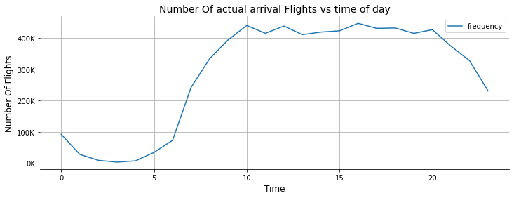

### 08. Flight dataset CRSArrTime column:

```
range :  00:00 AM-11:59 PM
scheduled arrival time (local, hh:mm AM/PM)
```

```
count      6851832
unique        1373
top       04:30 PM
freq         23420
Name: CRSArrTime, dtype: object
```

### line plot indicate the number of scheduled arrival flights over the day time

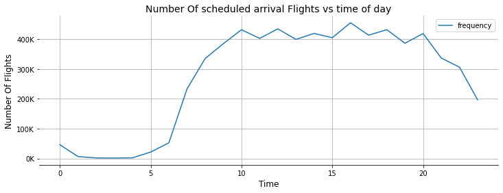

> peak crowd start from 10:00 AM to 08:00 PM

### 09. Flight dataset UniqueCarrier column:

```
range :  1 - 20 string
unique carrier code
```

#### Bar plot indicate the number of flights per carrier

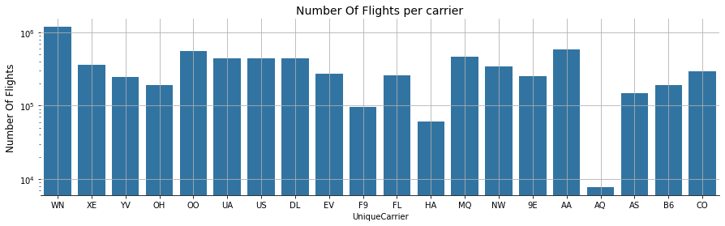

> apperantly WN carrier have the most share of flights about 1,186,911 flight.

### 10. Flight dataset FlightNum column:

```
range : string
flight number
```

```
count     6851832
unique       7532
top           152
freq         4757
Name: FlightNum, dtype: object
```

### 11. Flight dataset TailNum column:

```
range : string
plane tail number :
aircraft registration, unique aircraft identifier
```

```
count     6851832
unique       5366
top        N476HA
freq         4701
Name: TailNum, dtype: object
```

### 12. Flight dataset ActualElapsedTime column:

```
range : in minutes
ActualElapsedTime
```

```
count    6851832.00
mean         127.31
std           70.18
min           12.00
25%           77.00
50%          110.00
75%          157.00
max         1379.00
Name: ActualElapsedTime, dtype: float64
```

### 13. Flight dataset CRSElapsedTime column:

```
range : in minutes
CRSElapsedTime
```

#### histogram indicate the density of scheduled ElapsedTime for flights per distance

[figure not shown]

### 14. Flight dataset AirTime column:

```
range : in minutes
```

#### histogram indicate the density of arive Time for flights per distance

[figure not shown]

### 15. Flight dataset ArrDelay column:

```
range : in minutes
arrival delay:
A flight is counted as "on time" if it operated less than 15 minutes later the scheduled time shown in the carriers' Computerized Reservations Systems (CRS).
```

#### histogram indicate the density of arive delayTime for flights per distance

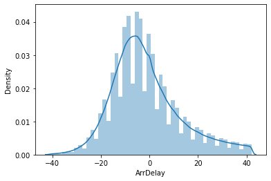

### 16. Flight dataset DepDelay column:

```
range : in minutes
departure delay:
```

```
count    5731953.0
mean           1.5
std           11.1
min          -92.0
25%           -5.0
50%           -2.0
75%            3.0
max          100.0
Name: DepDelay, dtype: float64
```

#### histogram indicate the density of depate delay Time for flights per distance

[figure not shown]

### 17. Flight dataset Origin column:

```
range : string
origin IATA airport code
```

### 18. Flight dataset Dest column:

```
range : string
destination IATA airport code
```

### 19. Flight dataset Distance column:

```
range : in miles
Distance
```

### 20. Flight dataset TaxiIn column:

```
range : in minutes
taxi in time
```

### 21. Flight dataset TaxiOut column:

```
range : in minutes
taxi out time
```

```
count    4857065.0
mean          15.3
std            8.3
min            0.0
25%           10.0
50%           13.0
75%           18.0
max          151.0
Name: TaxiOut, dtype: float64
```

### 25. Flight dataset CarrierDelay column:

```
range : in minutes
- Carrier delay is within the control of the air carrier.
- Examples of occurrences that may determine carrier delay are:
    - aircraft cleaning, aircraft damage, awaiting the arrival of connecting passengers or crew,
    - baggage, bird strike, cargo loading, catering, computer, outage-carrier equipment,
    - crew legality (pilot or attendant rest), damage by hazardous goods, engineering inspection, fueling,
    - handling disabled passengers, late crew, lavatory servicing, maintenance, oversales,
    - potable water servicing, removal of unruly passenger, slow boarding or seating,
    - stowing carry-on baggage, weight and balance delays.
```

```
count    4598311.000
mean           0.123
std            1.245
min            0.000
25%            0.000
50%            0.000
75%            0.000
max           42.000
Name: CarrierDelay, dtype: float64
```

### 26. Flight dataset WeatherDelay column:

```
range : in minutes
Weather delay is caused by extreme or hazardous weather conditions that are forecasted or
manifest themselves on point of departure, enroute, or on point of arrival.
```

```
count    4598311.000
mean           0.010
std            0.362
min            0.000
25%            0.000
50%            0.000
75%            0.000
max           42.000
Name: WeatherDelay, dtype: float64
```

### 27. Flight dataset NASDelay column:

```
range : in minutes
Delay that is within the control of the National Airspace System (NAS) may include:
non-extreme weather conditions, airport operations, heavy traffic volume, air traffic control, etc.
```

```
count    4598311.000
mean           0.525
std            3.172
min            0.000
25%            0.000
50%            0.000
75%            0.000
max           42.000
Name: NASDelay, dtype: float64
```

### 28. Flight dataset SecurityDelay column:

```
range : in minutes
Security delay is caused by evacuation of a terminal or concourse, re-boarding of aircraft because of security breach, inoperative screening equipment and/or long lines in excess of 29 minutes at screening areas.
```

```
count    4598311.000
mean           0.002
std            0.174
min            0.000
25%            0.000
50%            0.000
75%            0.000
max           40.000
Name: SecurityDelay, dtype: float64
```

### 29. Flight dataset LateAircraftDelay column:

```
range : in minutes
Arrival delay at an airport due to the late arrival of the same aircraft at a previous airport.
The ripple effect of an earlier delay at downstream airports is referred to as delay propagation.
```

```
count    4598311.000
mean           0.082
std            1.001
min            0.000
25%            0.000
50%            0.000
75%            0.000
max           42.000
Name: LateAircraftDelay, dtype: float64
```

## correlation matrix

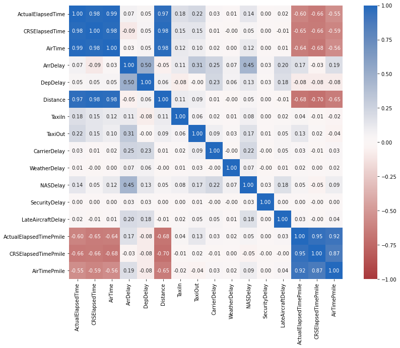